# teledom

#### Кодирование и шкалирование данных

Выделим числовые признаки и категориальные признаки, которые нужно выразить в цифровом значении.

```python
len(features.columns)
```

```
18
```

```python
features_num = ['MonthlyCharges','TotalCharges', 'Duration']
features_cat = ['Type', 'PaperlessBilling', 'PaymentMethod', 'SeniorCitizen',
       'gender', 'Partner', 'Dependents','InternetService',
       'OnlineSecurity', 'OnlineBackup', 'DeviceProtection',
       'TechSupport', 'StreamingTV', 'StreamingMovies', 'MultipleLines']

# сверим, что ничего не потеряли

len(features_num ) + len(features_cat)
```

```
18
```

```python
# создаем кодировщик. Будем использовать OrdinalEncoder, тк  у нас есть столбец данных InternetService с тремя значениями,
# чтобы не множить число кодировщиков

encoder = OrdinalEncoder()
```

```python
# отдельно кодируем тренировочные данные

features_train_cat = pd.DataFrame(encoder.fit_transform(features_train[features_cat]),
                                   columns=features_cat)
features_train_cat.head()
```

|  | Type | PaperlessBilling | PaymentMethod | SeniorCitizen | gender | Partner | Dependents | InternetService | OnlineSecurity | OnlineBackup | DeviceProtection | TechSupport | StreamingTV | StreamingMovies | MultipleLines |
| --- | --- | --- | --- | --- | --- | --- | --- | --- | --- | --- | --- | --- | --- | --- | --- |
| 0 | 0.0 | 1.0 | 1.0 | 0.0 | 1.0 | 1.0 | 1.0 | 1.0 | 0.0 | 1.0 | 1.0 | 0.0 | 1.0 | 0.0 | 0.0 |
| 1 | 2.0 | 1.0 | 0.0 | 1.0 | 1.0 | 1.0 | 0.0 | 0.0 | 1.0 | 1.0 | 1.0 | 1.0 | 1.0 | 1.0 | 0.0 |
| 2 | 1.0 | 1.0 | 1.0 | 0.0 | 1.0 | 1.0 | 1.0 | 0.0 | 0.0 | 0.0 | 0.0 | 0.0 | 0.0 | 0.0 | 0.0 |
| 3 | 2.0 | 0.0 | 0.0 | 0.0 | 1.0 | 1.0 | 0.0 | 0.0 | 1.0 | 1.0 | 1.0 | 0.0 | 0.0 | 0.0 | 0.0 |
| 4 | 2.0 | 1.0 | 0.0 | 0.0 | 1.0 | 0.0 | 0.0 | 1.0 | 0.0 | 1.0 | 1.0 | 0.0 | 1.0 | 1.0 | 1.0 |

```python
# отдельно тест данные

features_test_cat = pd.DataFrame(encoder.transform(features_test[features_cat]),
                            columns=features_cat)

features_test_cat.head()
```

|  | Type | PaperlessBilling | PaymentMethod | SeniorCitizen | gender | Partner | Dependents | InternetService | OnlineSecurity | OnlineBackup | DeviceProtection | TechSupport | StreamingTV | StreamingMovies | MultipleLines |
| --- | --- | --- | --- | --- | --- | --- | --- | --- | --- | --- | --- | --- | --- | --- | --- |
| 0 | 2.0 | 0.0 | 1.0 | 1.0 | 1.0 | 1.0 | 0.0 | 1.0 | 1.0 | 1.0 | 1.0 | 0.0 | 1.0 | 1.0 | 1.0 |
| 1 | 0.0 | 1.0 | 1.0 | 0.0 | 1.0 | 0.0 | 0.0 | 1.0 | 1.0 | 0.0 | 0.0 | 0.0 | 0.0 | 0.0 | 0.0 |
| 2 | 2.0 | 1.0 | 0.0 | 0.0 | 1.0 | 1.0 | 1.0 | 0.0 | 0.0 | 1.0 | 1.0 | 1.0 | 1.0 | 1.0 | 1.0 |
| 3 | 0.0 | 1.0 | 3.0 | 1.0 | 1.0 | 1.0 | 0.0 | 1.0 | 0.0 | 1.0 | 1.0 | 0.0 | 0.0 | 0.0 | 0.0 |
| 4 | 2.0 | 0.0 | 3.0 | 0.0 | 1.0 | 0.0 | 0.0 | 2.0 | 0.0 | 0.0 | 0.0 | 0.0 | 0.0 | 0.0 | 1.0 |

```python
# шкалируем  цифровые данные так же отдельно для трейн и тест

scaler=StandardScaler()
scaler.fit(features_train[features_num])


features_train_num= pd.DataFrame(scaler.transform(features_train[features_num]),
                                   columns=features_num)

features_train_num.head()
```

|  | MonthlyCharges | TotalCharges | Duration |
| --- | --- | --- | --- |
| 0 | 0.853574 | 1.123047 | 0.875812 |
| 1 | 0.696285 | 1.275859 | 1.190363 |
| 2 | -1.303777 | -0.530234 | 0.427504 |
| 3 | -0.745813 | 0.568712 | 1.903247 |
| 4 | 1.328755 | 2.130111 | 1.501974 |

```python
features_test_num= pd.DataFrame(scaler.transform(features_test[features_num]),
                                   columns=features_num)

features_test_num.head()
```

|  | MonthlyCharges | TotalCharges | Duration |
| --- | --- | --- | --- |
| 0 | 1.452931 | 1.677561 | 0.965474 |
| 1 | 0.302233 | -0.501666 | -0.735158 |
| 2 | 0.648270 | 1.596455 | 1.591636 |
| 3 | 0.497603 | -0.730012 | -1.002673 |
| 4 | -1.325301 | -0.915248 | -1.004143 |

Объединяем кодированные и шкалированные данные из таблиц и столбец SeniorCitizen в features_test_new и features_train_new Проверим размерности и данные

```python
features_train_new = pd.concat([features_train_cat, features_train_num], sort = False, axis =1)

features_train_new.head()
```

|  | Type | PaperlessBilling | PaymentMethod | SeniorCitizen | gender | Partner | Dependents | InternetService | OnlineSecurity | OnlineBackup | DeviceProtection | TechSupport | StreamingTV | StreamingMovies | MultipleLines | MonthlyCharges | TotalCharges | Duration |
| --- | --- | --- | --- | --- | --- | --- | --- | --- | --- | --- | --- | --- | --- | --- | --- | --- | --- | --- |
| 0 | 0.0 | 1.0 | 1.0 | 0.0 | 1.0 | 1.0 | 1.0 | 1.0 | 0.0 | 1.0 | 1.0 | 0.0 | 1.0 | 0.0 | 0.0 | 0.853574 | 1.123047 | 0.875812 |
| 1 | 2.0 | 1.0 | 0.0 | 1.0 | 1.0 | 1.0 | 0.0 | 0.0 | 1.0 | 1.0 | 1.0 | 1.0 | 1.0 | 1.0 | 0.0 | 0.696285 | 1.275859 | 1.190363 |
| 2 | 1.0 | 1.0 | 1.0 | 0.0 | 1.0 | 1.0 | 1.0 | 0.0 | 0.0 | 0.0 | 0.0 | 0.0 | 0.0 | 0.0 | 0.0 | -1.303777 | -0.530234 | 0.427504 |
| 3 | 2.0 | 0.0 | 0.0 | 0.0 | 1.0 | 1.0 | 0.0 | 0.0 | 1.0 | 1.0 | 1.0 | 0.0 | 0.0 | 0.0 | 0.0 | -0.745813 | 0.568712 | 1.903247 |
| 4 | 2.0 | 1.0 | 0.0 | 0.0 | 1.0 | 0.0 | 0.0 | 1.0 | 0.0 | 1.0 | 1.0 | 0.0 | 1.0 | 1.0 | 1.0 | 1.328755 | 2.130111 | 1.501974 |

```python
features_train_new.info()
```

```
<class 'pandas.core.frame.DataFrame'>
RangeIndex: 5282 entries, 0 to 5281
Data columns (total 18 columns):
 #   Column            Non-Null Count  Dtype
---  ------            --------------  -----
 0   Type              5282 non-null   float64
 1   PaperlessBilling  5282 non-null   float64
 2   PaymentMethod     5282 non-null   float64
 3   SeniorCitizen     5282 non-null   float64
 4   gender            5282 non-null   float64
 5   Partner           5282 non-null   float64
 6   Dependents        5282 non-null   float64
 7   InternetService   5282 non-null   float64
 8   OnlineSecurity    5282 non-null   float64
 9   OnlineBackup      5282 non-null   float64
 10  DeviceProtection  5282 non-null   float64
 11  TechSupport       5282 non-null   float64
 12  StreamingTV       5282 non-null   float64
 13  StreamingMovies   5282 non-null   float64
 14  MultipleLines     5282 non-null   float64
 15  MonthlyCharges    5282 non-null   float64
 16  TotalCharges      5282 non-null   float64
 17  Duration          5282 non-null   float64
dtypes: float64(18)
memory usage: 742.9 KB
```

```python
round(features_train_new.shape[0]/features.shape[0],2)
```

```
0.75
```

```python
features_train_new.isna().sum()
```

```
Type                0
PaperlessBilling    0
PaymentMethod       0
SeniorCitizen       0
gender              0
Partner             0
Dependents          0
InternetService     0
OnlineSecurity      0
OnlineBackup        0
DeviceProtection    0
TechSupport         0
StreamingTV         0
StreamingMovies     0
MultipleLines       0
MonthlyCharges      0
TotalCharges        0
Duration            0
dtype: int64
```

Тоже самое проверим для тестовых признаков.

```python
features_test_new = pd.concat([features_test_cat, features_test_num], sort = False, axis =1)

features_test_new.head()
```

|  | Type | PaperlessBilling | PaymentMethod | SeniorCitizen | gender | Partner | Dependents | InternetService | OnlineSecurity | OnlineBackup | DeviceProtection | TechSupport | StreamingTV | StreamingMovies | MultipleLines | MonthlyCharges | TotalCharges | Duration |
| --- | --- | --- | --- | --- | --- | --- | --- | --- | --- | --- | --- | --- | --- | --- | --- | --- | --- | --- |
| 0 | 2.0 | 0.0 | 1.0 | 1.0 | 1.0 | 1.0 | 0.0 | 1.0 | 1.0 | 1.0 | 1.0 | 0.0 | 1.0 | 1.0 | 1.0 | 1.452931 | 1.677561 | 0.965474 |
| 1 | 0.0 | 1.0 | 1.0 | 0.0 | 1.0 | 0.0 | 0.0 | 1.0 | 1.0 | 0.0 | 0.0 | 0.0 | 0.0 | 0.0 | 0.0 | 0.302233 | -0.501666 | -0.735158 |
| 2 | 2.0 | 1.0 | 0.0 | 0.0 | 1.0 | 1.0 | 1.0 | 0.0 | 0.0 | 1.0 | 1.0 | 1.0 | 1.0 | 1.0 | 1.0 | 0.648270 | 1.596455 | 1.591636 |
| 3 | 0.0 | 1.0 | 3.0 | 1.0 | 1.0 | 1.0 | 0.0 | 1.0 | 0.0 | 1.0 | 1.0 | 0.0 | 0.0 | 0.0 | 0.0 | 0.497603 | -0.730012 | -1.002673 |
| 4 | 2.0 | 0.0 | 3.0 | 0.0 | 1.0 | 0.0 | 0.0 | 2.0 | 0.0 | 0.0 | 0.0 | 0.0 | 0.0 | 0.0 | 1.0 | -1.325301 | -0.915248 | -1.004143 |

```python
features_test_new.info()
```

```
<class 'pandas.core.frame.DataFrame'>
RangeIndex: 1761 entries, 0 to 1760
Data columns (total 18 columns):
 #   Column            Non-Null Count  Dtype
---  ------            --------------  -----
 0   Type              1761 non-null   float64
 1   PaperlessBilling  1761 non-null   float64
 2   PaymentMethod     1761 non-null   float64
 3   SeniorCitizen     1761 non-null   float64
 4   gender            1761 non-null   float64
 5   Partner           1761 non-null   float64
 6   Dependents        1761 non-null   float64
 7   InternetService   1761 non-null   float64
 8   OnlineSecurity    1761 non-null   float64
 9   OnlineBackup      1761 non-null   float64
 10  DeviceProtection  1761 non-null   float64
 11  TechSupport       1761 non-null   float64
 12  StreamingTV       1761 non-null   float64
 13  StreamingMovies   1761 non-null   float64
 14  MultipleLines     1761 non-null   float64
 15  MonthlyCharges    1761 non-null   float64
 16  TotalCharges      1761 non-null   float64
 17  Duration          1761 non-null   float64
dtypes: float64(18)
memory usage: 247.8 KB
```

```python
round(features_test_new.shape[0]/features.shape[0],2)
```

```
0.25
```

```python
features_test_new.isna().sum()
```

```
Type                0
PaperlessBilling    0
PaymentMethod       0
SeniorCitizen       0
gender              0
Partner             0
Dependents          0
InternetService     0
OnlineSecurity      0
OnlineBackup        0
DeviceProtection    0
TechSupport         0
StreamingTV         0
StreamingMovies     0
MultipleLines       0
MonthlyCharges      0
TotalCharges        0
Duration            0
dtype: int64
```

Данные готовы к обучению моделей.

#### Выводы подготовки признаков

- Добавили столбец Duration - длительность договора, выраженная в днях
- Удалили из начальных данных столбцы 'BeginDate', 'EndDate', 'customerID' как ненужные для обучения
- Разделили выборку на тестовую и обучающую в соотношении 25/75
- Выделили цифровые признаки -'MonthlyCharges' -'TotalCharges'
  - 'Duration'
- Выделили категориальные признаки
  - 'Type'
  - 'PaperlessBilling'
  - 'PaymentMethod'
  - 'SeniorCitizen'
  - 'gender'
  - 'Partner'
  - 'Dependents'
  - 'InternetService'
  - 'OnlineSecurity'
  - 'OnlineBackup'
  - 'DeviceProtection',
  - 'TechSupport',
  - 'StreamingTV'
  - 'StreamingMovies'
  - 'MultipleLines'
- Обучили OrdinalEncoder() на обучающей выборке и кодировали данные обучающей выборки
- Отдельно кодировали данные тестовой выборки
- Обучили StandardScaler() на обучающей выборке и шкалировали данные обучающей выборки
- Отдельно шкалировали данные тестовой выборки
- Объединили кодированные и шкалированные данные в датасеты обучающей и тестовой выборки

### Построение моделей

#### LogisticRegression

```python
LR_model = LogisticRegression()
LR_params = {'C':([0.001, 0.01, 0.1, 1, 10, 100, 1000]),
             'random_state': ([RS]),
             'max_iter': ([1000]),
             'class_weight':['balanced']}

LR_clf = GridSearchCV(LR_model, LR_params, scoring='roc_auc',cv=5)
LR_clf.fit(features_train_new, target_train)
```

```
GridSearchCV(cv=5, estimator=LogisticRegression(),
             param_grid={'C': [0.001, 0.01, 0.1, 1, 10, 100, 1000],
                         'class_weight': ['balanced'], 'max_iter': [1000],
                         'random_state': [61123]},
             scoring='roc_auc')
```

```python
print("Лучшие параметры модели:")
print()
print(LR_clf.best_params_)

print('roc_auc:', round(LR_clf.best_score_, 2))
```

```
Лучшие параметры модели:

{'C': 10, 'class_weight': 'balanced', 'max_iter': 1000, 'random_state': 61123}
roc_auc: 0.75
```

#### RandomForestClassifier

```python
RF_model = RandomForestClassifier()

RF_params = {'n_estimators': [10,50,100],
             'max_depth': [5,10,20],
             'min_samples_split': [2, 10],
             'min_samples_leaf': [2, 10],
             'random_state': [RS],
             'class_weight': ['balanced']}

RF_clf = GridSearchCV(RF_model, RF_params, scoring='roc_auc', cv=5)

RF_clf.fit(features_train_new, target_train)
```

```
GridSearchCV(cv=5, estimator=RandomForestClassifier(),
             param_grid={'class_weight': ['balanced'], 'max_depth': [5, 10, 20],
                         'min_samples_leaf': [2, 10],
                         'min_samples_split': [2, 10],
                         'n_estimators': [10, 50, 100],
                         'random_state': [61123]},
             scoring='roc_auc')
```

```python
print("Лучшие параметры модели:")
print()
print(RF_clf.best_params_)

print('roc_auc:', round(RF_clf.best_score_, 2))
```

```
Лучшие параметры модели:

{'class_weight': 'balanced', 'max_depth': 10, 'min_samples_leaf': 2, 'min_samples_split': 10, 'n_estimators': 100, 'random_state': 61123}
roc_auc: 0.82
```

#### CatBoostClassifier

Проверим значение CatBoostClassifier на сырых данных.

```python
CB_model = CatBoostClassifier(cat_features=features_cat, random_state=RS)

CB_params = {'verbose': [False],
             'iterations': [300],
             'learning_rate': [0.1, 0.3],
             'l2_leaf_reg': [3, 9]
              }

CB_clf  = GridSearchCV(CB_model, CB_params, scoring='roc_auc', cv=5)

CB_clf.fit(features_train, target_train)
```

```
GridSearchCV(cv=5,
             estimator=<catboost.core.CatBoostClassifier object at 0x7fc41bd6e5e0>,
             param_grid={'iterations': [300], 'l2_leaf_reg': [3, 9],
                         'learning_rate': [0.1, 0.3], 'verbose': [False]},
             scoring='roc_auc')
```

```python
print("Лучшие параметры модели:")
print()
print(CB_clf.best_params_)

print('roc_auc:', round(CB_clf.best_score_, 2))
```

```
Лучшие параметры модели:

{'iterations': 300, 'l2_leaf_reg': 3, 'learning_rate': 0.3, 'verbose': False}
roc_auc: 0.89
```

#### Тестирование лучшей модели

```python
pred_proba_CB = CB_clf.best_estimator_.predict_proba(features_test)[:, 1]
print('ROC-AUC: ', round(roc_auc_score(target_test, pred_proba_CB ), 2))
```

```
ROC-AUC:  0.93
```

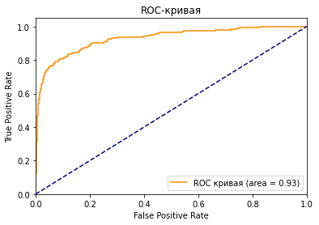

```
ROC_AUC Метрика:  0.928524313342656
```

```python
fpr, tpr, treshold = roc_curve(target_test, pred_proba_CB)
roc_auc = auc(fpr, tpr)
# строим график
plt.plot(fpr, tpr, color='darkorange',
         label='ROC кривая (area = %0.2f)' % roc_auc)
plt.plot([0, 1], [0, 1], color='navy', linestyle='--')
plt.xlim([0.0, 1.0])
plt.ylim([0.0, 1.05])
plt.xlabel('False Positive Rate')
plt.ylabel('True Positive Rate')
plt.title('ROC-кривая')
plt.legend(loc="lower right")
plt.show()
print('ROC_AUC Метрика: ',roc_auc_score(target_test, pred_proba_CB))
```

Модель оказала приемлемое значение метрики.